# HBAR-USD

## HBAR-USD today is +0200, 2025-11-13, 03:49:36

This crypto forecast was generated by gemini-2.0-flash API

## Daily Chart

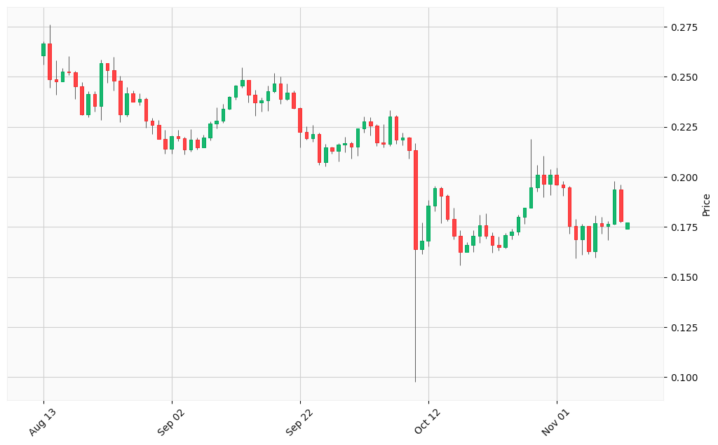

## Hourly Chart

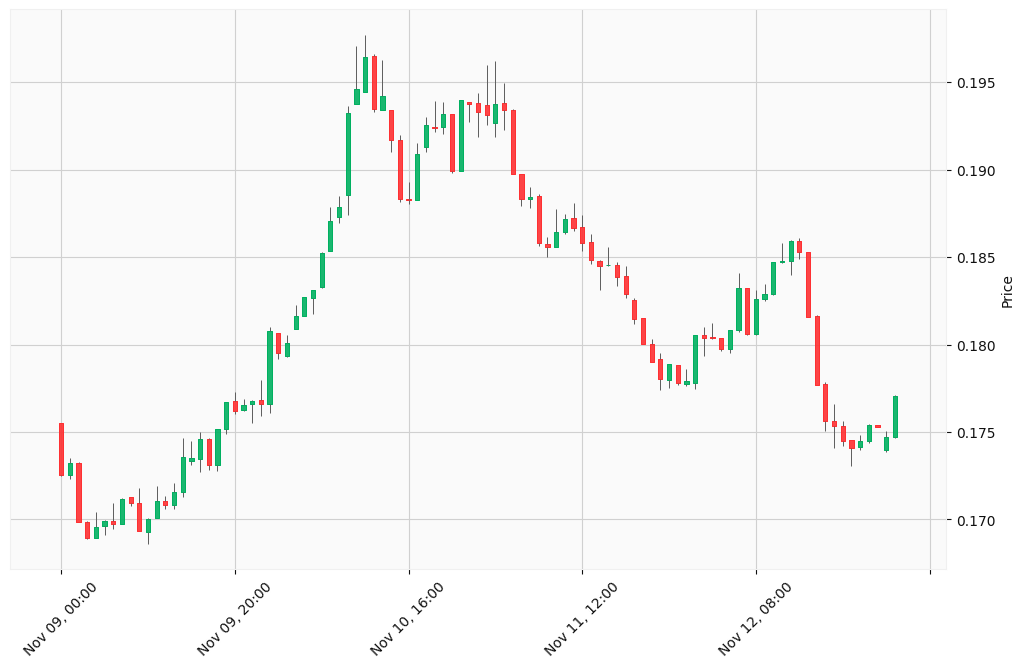

Okay, I will analyze the provided HBAR-USD charts and generate trading signals based on the steps you’ve outlined. Given that I cannot access real-time data or external news sources directly, I will simulate those aspects based on the data provided and general market knowledge.

First, let’s define some functions to assist with calculations.

### Technical Analysis Functions

```python
def calculate_rsi(prices, period=14):
    """Calculates the Relative Strength Index (RSI)."""
    deltas = [prices[i+1] - prices[i] for i in range(len(prices)-1)]
    seed = deltas[:period]
    up = sum([d for d in seed if d > 0]) / period
    down = -sum([d for d in seed if d < 0]) / period
    rs = up / down if down != 0 else 0
    rsi = 100 - (100 / (1 + rs))

    for i in range(period, len(deltas)):
        delta = deltas[i]
        if delta > 0:
            up = (up * (period - 1) + delta) / period
            down = down * (period - 1) / period
        else:
            down = (down * (period - 1) - delta) / period
            up = up * (period - 1) / period

        rs = up / down if down != 0 else 0
        rsi = 100 - (100 / (1 + rs))

    return rsi

def calculate_sma(prices, period=20):
    """Calculates the Simple Moving Average (SMA)."""
    if len(prices) < period:
        return None
    return sum(prices[-period:]) / period

def calculate_ema(prices, period=20):
    """Calculates the Exponential Moving Average (EMA)."""
    if len(prices) < period:
        return None

    sma = sum(prices[:period]) / period
    ema = sma

    alpha = 2 / (period + 1)

    for price in prices[period:]:
        ema = alpha * price + (1 - alpha) * ema

    return ema
```